# Trial 1B - full data set

Load packages:

```r
library(pacman)
p_load(psych, haven, tidyverse, GPArotation, multilevel)
```

Import data:

```r
surveyfull <- read_spss("../data/The Effect of Various Factors on Childhood Experiences and Adult Perso 3 full.sav")
```

Create STS data frame with full data set:

```r
stsfull <- dplyr::select(surveyfull, q0046_0001, q0047_0001, q0048_0001, q0049_0001, q0050_0001, q0051_0001, q0052_0001, q0053_0001, q0054_0001, q0055_0001, q0056_0001, q0057_0001, q0058_0001, q0059_0001, q0060_0001, q0061_0001, q0062_0001, q0063_0001, q0064_0001, q0065_0001, q0066_0001, q0067_0001, q0068_0001, q0069_0001, q0070_0001, q0071_0001, q0072_0001, q0073_0001, q0074_0001, q0075_0001, q0076_0001, q0077_0001, q0078_0001, q0079_0001, q0080_0001, q0081_0001, q0082_0001, q0083_0001, q0084_0001, q0085_0001, q0086_0001, q0087_0001, q0088_0001, q0089_0001, q0090_0001)
```

```r
stsfull.dat <- as.data.frame(stsfull)
```

Descriptive stats:

```r
describe(stsfull.dat)
```

|  | vars | n | mean | sd | median | trimmed | mad | min | max | range | skew | kurtosis | se |
| --- | --- | --- | --- | --- | --- | --- | --- | --- | --- | --- | --- | --- | --- |
| q0046_0001 | 1 | 128 | 0.07 | 0.38 | 0 | 0.00 | 0.00 | 0 | 3 | 3 | 5.84 | 35.43 | 0.03 |
| q0047_0001 | 2 | 128 | 0.20 | 0.70 | 0 | 0.00 | 0.00 | 0 | 3 | 3 | 3.35 | 9.80 | 0.06 |
| q0048_0001 | 3 | 128 | 1.76 | 1.43 | 3 | 1.82 | 0.00 | 0 | 3 | 3 | -0.35 | -1.83 | 0.13 |
| q0049_0001 | 4 | 128 | 0.60 | 1.09 | 0 | 0.39 | 0.00 | 0 | 3 | 3 | 1.45 | 0.38 | 0.10 |
| q0050_0001 | 5 | 128 | 0.67 | 1.10 | 0 | 0.48 | 0.00 | 0 | 3 | 3 | 1.26 | -0.06 | 0.10 |
| q0051_0001 | 6 | 128 | 0.74 | 1.14 | 0 | 0.57 | 0.00 | 0 | 3 | 3 | 1.21 | -0.18 | 0.10 |
| q0052_0001 | 7 | 128 | 0.74 | 1.12 | 0 | 0.57 | 0.00 | 0 | 3 | 3 | 1.14 | -0.33 | 0.10 |
| q0053_0001 | 8 | 128 | 0.34 | 0.87 | 0 | 0.09 | 0.00 | 0 | 3 | 3 | 2.41 | 4.25 | 0.08 |
| q0054_0001 | 9 | 128 | 0.22 | 0.61 | 0 | 0.06 | 0.00 | 0 | 3 | 3 | 3.08 | 9.32 | 0.05 |
| q0055_0001 | 10 | 128 | 0.25 | 0.68 | 0 | 0.06 | 0.00 | 0 | 3 | 3 | 2.70 | 6.34 | 0.06 |

[output cut: 35 more lines]

Trial analysis on survey full: Using PA

```
Parallel analysis suggests that the number of factors =  7  and the number of components =  NA
```

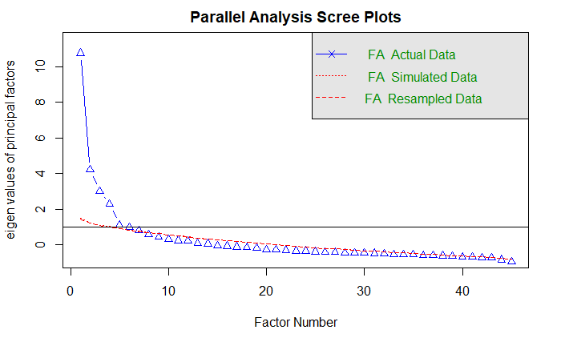

```r
parallel.s4 <- fa.parallel(stsfull, fm = 'pa', fa = 'fa')
```

EFA PAF 5 factors:

```r
fivefactor.pa.full <- fa(stsfull,nfactors = 5,rotate = "oblimin",fm="pa")
print(fivefactor.pa.full)
```

```
Factor Analysis using method =  pa
Call: fa(r = stsfull, nfactors = 5, rotate = "oblimin", fm = "pa")
Standardized loadings (pattern matrix) based upon correlation matrix
```

|  | PA1 | PA2 | PA4 | PA3 | PA5 | h2 | u2 | com |
| --- | --- | --- | --- | --- | --- | --- | --- | --- |
| q0046_0001 | 0.11 | -0.13 | 0.29 | -0.15 | 0.04 | 0.11544704 | 0.8845530 | 2.404957 |
| q0047_0001 | -0.25 | 0.61 | 0.18 | -0.21 | -0.14 | 0.46897784 | 0.5310222 | 1.922249 |
| q0048_0001 | 0.02 | -0.13 | -0.17 | 0.56 | 0.05 | 0.35103533 | 0.6489647 | 1.328333 |
| q0049_0001 | -0.15 | 0.42 | 0.42 | -0.10 | 0.12 | 0.47243797 | 0.5275620 | 2.505796 |
| q0050_0001 | -0.07 | 0.11 | 0.58 | 0.09 | 0.27 | 0.53978754 | 0.4602125 | 1.599164 |
| q0051_0001 | -0.07 | 0.22 | 0.61 | 0.08 | 0.22 | 0.61934963 | 0.3806504 | 1.627461 |
| q0052_0001 | -0.05 | 0.11 | 0.71 | 0.12 | 0.21 | 0.70113488 | 0.2988651 | 1.302507 |
| q0053_0001 | 0.15 | -0.10 | 0.70 | 0.06 | -0.06 | 0.51191231 | 0.4880877 | 1.161663 |
| q0054_0001 | 0.10 | -0.09 | 0.85 | 0.05 | -0.08 | 0.70716365 | 0.2928363 | 1.075663 |
| q0055_0001 | 0.18 | -0.06 | 0.88 | 0.06 | -0.15 | 0.79490404 | 0.2050960 | 1.168536 |

[output cut: 35 more lines]

```
                       PA1  PA2  PA4  PA3  PA5
SS loadings           6.57 5.73 4.42 3.24 3.27
Proportion Var        0.15 0.13 0.10 0.07 0.07
Cumulative Var        0.15 0.27 0.37 0.44 0.52
Proportion Explained  0.28 0.25 0.19 0.14 0.14
Cumulative Proportion 0.28 0.53 0.72 0.86 1.00

 With factor correlations of
     PA1   PA2  PA4   PA3  PA5
PA1 1.00  0.18 0.16  0.04 0.22
PA2 0.18  1.00 0.23 -0.01 0.33
PA4 0.16  0.23 1.00  0.11 0.22
PA3 0.04 -0.01 0.11  1.00 0.10
PA5 0.22  0.33 0.22  0.10 1.00

Mean item complexity =  1.7
Test of the hypothesis that 5 factors are sufficient.

The degrees of freedom for the null model are  990  and the objective function was  39.18 with Chi Square of  4355.06
The degrees of freedom for the model are 775  and the objective function was  14.59

The root mean square of the residuals (RMSR) is  0.06
The df corrected root mean square of the residuals is  0.06

The harmonic number of observations is  128 with the empirical chi square  818.48  with prob <  0.14
The total number of observations was  128  with Likelihood Chi Square =  1573.03  with prob <  1.4e-56

Tucker Lewis Index of factoring reliability =  0.685
RMSEA index =  0.105  and the 90 % confidence intervals are  0.084 NA
BIC =  -2187.3
Fit based upon off diagonal values = 0.96
Measures of factor score adequacy
                                                   PA1  PA2  PA4
Correlation of (regression) scores with factors   0.97 0.97 0.97
Multiple R square of scores with factors          0.94 0.94 0.93
Minimum correlation of possible factor scores     0.89 0.89 0.86
                                                   PA3  PA5
Correlation of (regression) scores with factors   0.97 0.93
Multiple R square of scores with factors          0.95 0.87
Minimum correlation of possible factor scores     0.89 0.74
```

Supress factor loadings below 0.49

```r
print(fivefactor.pa.full$loadings,cutoff = 0.49)
```

```
Loadings:
           PA1    PA2    PA4    PA3    PA5
q0046_0001
q0047_0001         0.613
q0048_0001                       0.560
q0049_0001
q0050_0001                0.576
q0051_0001                0.607
q0052_0001                0.709
q0053_0001                0.699
q0054_0001                0.845
q0055_0001                0.876
q0056_0001                       0.847
q0057_0001                       0.924
q0058_0001                       0.913
q0059_0001  0.526
q0060_0001
q0061_0001
q0062_0001
q0063_0001
q0064_0001
q0065_0001
q0066_0001
q0067_0001  0.713
q0068_0001         0.788
q0069_0001  0.676
q0070_0001         0.839
q0071_0001  0.792
q0072_0001         0.771
q0073_0001
q0074_0001
q0075_0001         0.658
q0076_0001  0.699
q0077_0001         0.776
q0078_0001
q0079_0001  0.537
q0080_0001  0.665
q0081_0001  0.817
q0082_0001         0.831
q0083_0001
q0084_0001         0.544
q0085_0001  0.515
q0086_0001
q0087_0001                              0.624
q0088_0001
q0089_0001
q0090_0001  0.551

                 PA1   PA2   PA4   PA3   PA5
SS loadings    6.162 5.292 4.063 3.208 2.600
Proportion Var 0.137 0.118 0.090 0.071 0.058
Cumulative Var 0.137 0.255 0.345 0.416 0.474
```

EFA PAF 4 factors:

```r
fourfactor.pa.full <- fa(stsfull,nfactors = 4,rotate = "oblimin",fm="pa")
print(fourfactor.pa.full)
```

```
Factor Analysis using method =  pa
Call: fa(r = stsfull, nfactors = 4, rotate = "oblimin", fm = "pa")
Standardized loadings (pattern matrix) based upon correlation matrix
```

|  | PA1 | PA2 | PA4 | PA3 | h2 | u2 | com |
| --- | --- | --- | --- | --- | --- | --- | --- |
| q0046_0001 | 0.12 | -0.12 | 0.30 | -0.15 | 0.11571130 | 0.8842887 | 2.200674 |
| q0047_0001 | -0.28 | 0.59 | 0.14 | -0.25 | 0.43687451 | 0.5631255 | 1.948514 |
| q0048_0001 | 0.04 | -0.14 | -0.16 | 0.57 | 0.35632462 | 0.6436754 | 1.304000 |
| q0049_0001 | -0.10 | 0.49 | 0.42 | -0.09 | 0.47489916 | 0.5251008 | 2.117186 |
| q0050_0001 | 0.02 | 0.23 | 0.60 | 0.14 | 0.52863110 | 0.4713689 | 1.418240 |
| q0051_0001 | 0.00 | 0.33 | 0.62 | 0.12 | 0.62141458 | 0.3785854 | 1.601098 |
| q0052_0001 | 0.02 | 0.21 | 0.73 | 0.15 | 0.70550893 | 0.2944911 | 1.261279 |
| q0053_0001 | 0.13 | -0.12 | 0.68 | 0.03 | 0.48706715 | 0.5129329 | 1.139537 |
| q0054_0001 | 0.07 | -0.11 | 0.82 | 0.02 | 0.67272814 | 0.3272719 | 1.053873 |
| q0055_0001 | 0.14 | -0.12 | 0.83 | 0.00 | 0.70979447 | 0.2902055 | 1.096468 |

[output cut: 35 more lines]

```
                       PA1  PA2  PA4  PA3
SS loadings           7.64 6.34 4.36 3.33
Proportion Var        0.17 0.14 0.10 0.07
Cumulative Var        0.17 0.31 0.41 0.48
Proportion Explained  0.35 0.29 0.20 0.15
Cumulative Proportion 0.35 0.65 0.85 1.00

 With factor correlations of
     PA1  PA2  PA4  PA3
PA1 1.00 0.25 0.20 0.05
PA2 0.25 1.00 0.24 0.04
PA4 0.20 0.24 1.00 0.12
PA3 0.05 0.04 0.12 1.00

Mean item complexity =  1.5
Test of the hypothesis that 4 factors are sufficient.

The degrees of freedom for the null model are  990  and the objective function was  39.18 with Chi Square of  4355.06
The degrees of freedom for the model are 816  and the objective function was  16.52

The root mean square of the residuals (RMSR) is  0.06
The df corrected root mean square of the residuals is  0.07

The harmonic number of observations is  128 with the empirical chi square  1060.72  with prob <  1.4e-08
The total number of observations was  128  with Likelihood Chi Square =  1792.93  with prob <  3.7e-75

Tucker Lewis Index of factoring reliability =  0.636
RMSEA index =  0.111  and the 90 % confidence intervals are  0.091 NA
BIC =  -2166.33
Fit based upon off diagonal values = 0.95
Measures of factor score adequacy
                                                   PA1  PA2  PA4
Correlation of (regression) scores with factors   0.97 0.97 0.96
Multiple R square of scores with factors          0.94 0.95 0.92
Minimum correlation of possible factor scores     0.89 0.89 0.84
                                                   PA3
Correlation of (regression) scores with factors   0.97
Multiple R square of scores with factors          0.93
Minimum correlation of possible factor scores     0.86
```

Supress factor loadings below 0.49

```r
print(fourfactor.pa.full$loadings,cutoff = 0.49)
```

```
Loadings:
           PA1    PA2    PA4    PA3
q0046_0001
q0047_0001         0.592
q0048_0001                       0.573
q0049_0001
q0050_0001                0.599
q0051_0001                0.619
q0052_0001                0.726
q0053_0001                0.679
q0054_0001                0.822
q0055_0001                0.827
q0056_0001                       0.864
q0057_0001                       0.870
q0058_0001                       0.886
q0059_0001  0.572
q0060_0001         0.560
q0061_0001
q0062_0001
q0063_0001
q0064_0001
q0065_0001  0.541
q0066_0001         0.635
q0067_0001  0.713
q0068_0001         0.717
q0069_0001  0.695
q0070_0001         0.753
q0071_0001  0.795
q0072_0001         0.746
q0073_0001
q0074_0001  0.532
q0075_0001         0.809
q0076_0001  0.675
q0077_0001         0.668
q0078_0001
q0079_0001  0.549
q0080_0001  0.655
q0081_0001  0.845
q0082_0001         0.882
q0083_0001  0.533
q0084_0001         0.616
q0085_0001  0.655
q0086_0001  0.538
q0087_0001
q0088_0001
q0089_0001  0.634
q0090_0001  0.669

                 PA1   PA2   PA4   PA3
SS loadings    7.308 5.986 4.019 3.299
Proportion Var 0.162 0.133 0.089 0.073
Cumulative Var 0.162 0.295 0.385 0.458
```

EFA PAF 3 factors:

```r
threefactor.pa.full <- fa(stsfull,nfactors = 3,rotate = "oblimin",fm="pa")
print(threefactor.pa.full)
```

```
Factor Analysis using method =  pa
Call: fa(r = stsfull, nfactors = 3, rotate = "oblimin", fm = "pa")
Standardized loadings (pattern matrix) based upon correlation matrix
```

|  | PA1 | PA2 | PA3 | h2 | u2 | com |
| --- | --- | --- | --- | --- | --- | --- |
| q0046_0001 | 0.15 | 0.00 | 0.06 | 0.02793862 | 0.9720614 | 1.327576 |
| q0047_0001 | -0.26 | 0.69 | -0.16 | 0.43630426 | 0.5636957 | 1.388153 |
| q0048_0001 | 0.01 | -0.29 | 0.38 | 0.19765143 | 0.8023486 | 1.860810 |
| q0049_0001 | -0.06 | 0.63 | 0.16 | 0.43473962 | 0.5652604 | 1.144349 |
| q0050_0001 | 0.07 | 0.40 | 0.47 | 0.46991969 | 0.5300803 | 1.995562 |
| q0051_0001 | 0.06 | 0.50 | 0.47 | 0.55922250 | 0.4407775 | 2.019800 |
| q0052_0001 | 0.09 | 0.41 | 0.56 | 0.59088393 | 0.4091161 | 1.895376 |
| q0053_0001 | 0.19 | 0.10 | 0.42 | 0.27062066 | 0.7293793 | 1.521047 |
| q0054_0001 | 0.15 | 0.16 | 0.48 | 0.33452802 | 0.6654720 | 1.440524 |
| q0055_0001 | 0.22 | 0.16 | 0.47 | 0.36219576 | 0.6378042 | 1.659872 |

[output cut: 35 more lines]

```
                       PA1  PA2  PA3
SS loadings           8.03 6.76 3.92
Proportion Var        0.18 0.15 0.09
Cumulative Var        0.18 0.33 0.42
Proportion Explained  0.43 0.36 0.21
Cumulative Proportion 0.43 0.79 1.00

 With factor correlations of
     PA1  PA2  PA3
PA1 1.00 0.30 0.13
PA2 0.30 1.00 0.14
PA3 0.13 0.14 1.00

Mean item complexity =  1.4
Test of the hypothesis that 3 factors are sufficient.

The degrees of freedom for the null model are  990  and the objective function was  39.18 with Chi Square of  4355.06
The degrees of freedom for the model are 858  and the objective function was  20.62

The root mean square of the residuals (RMSR) is  0.09
The df corrected root mean square of the residuals is  0.09

The harmonic number of observations is  128 with the empirical chi square  1932.31  with prob <  1.5e-84
The total number of observations was  128  with Likelihood Chi Square =  2250.79  with prob <  2.1e-125

Tucker Lewis Index of factoring reliability =  0.511
RMSEA index =  0.127  and the 90 % confidence intervals are  0.107 NA
BIC =  -1912.26
Fit based upon off diagonal values = 0.9
Measures of factor score adequacy
                                                   PA1  PA2  PA3
Correlation of (regression) scores with factors   0.97 0.97 0.94
Multiple R square of scores with factors          0.95 0.94 0.89
Minimum correlation of possible factor scores     0.89 0.88 0.77
```

Supress factor loadings below 0.49

```r
print(threefactor.pa.full$loadings,cutoff = 0.49)
```

```
Loadings:
           PA1    PA2    PA3
q0046_0001
q0047_0001         0.688
q0048_0001
q0049_0001         0.633
q0050_0001
q0051_0001         0.499
q0052_0001                0.560
q0053_0001
q0054_0001
q0055_0001
q0056_0001                0.702
q0057_0001                0.747
q0058_0001                0.781
q0059_0001  0.595
q0060_0001         0.616
q0061_0001
q0062_0001
q0063_0001
q0064_0001
q0065_0001  0.570
q0066_0001         0.677
q0067_0001  0.739
q0068_0001         0.657
q0069_0001  0.726
q0070_0001         0.659
q0071_0001  0.821
q0072_0001         0.649
q0073_0001
q0074_0001  0.561
q0075_0001         0.804
q0076_0001  0.698
q0077_0001         0.583
q0078_0001
q0079_0001  0.547
q0080_0001  0.651
q0081_0001  0.869
q0082_0001         0.856
q0083_0001  0.562
q0084_0001         0.753
q0085_0001  0.658
q0086_0001  0.541
q0087_0001  0.490
q0088_0001
q0089_0001  0.640
q0090_0001  0.670

                 PA1   PA2   PA3
SS loadings    7.750 6.488 3.774
Proportion Var 0.172 0.144 0.084
Cumulative Var 0.172 0.316 0.400
```

Consider psych sep only:

```r
stsfull_psych <- dplyr::select(surveyfull, q0059_0001, q0060_0001, q0061_0001, q0062_0001, q0063_0001, q0064_0001, q0065_0001, q0066_0001, q0067_0001, q0068_0001, q0069_0001, q0070_0001, q0071_0001, q0072_0001, q0073_0001, q0074_0001, q0075_0001, q0076_0001, q0077_0001, q0078_0001, q0079_0001, q0080_0001, q0081_0001, q0082_0001, q0083_0001, q0084_0001, q0085_0001, q0086_0001, q0087_0001, q0088_0001, q0089_0001, q0090_0001)
```

Trial analysis on survey full (psych only): Using PA

```
Parallel analysis suggests that the number of factors =  4  and the number of components =  NA
```

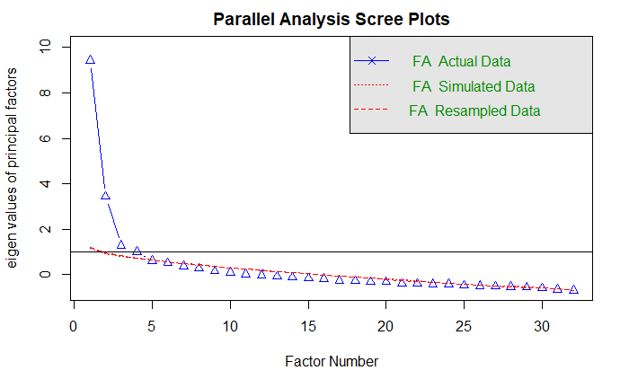

```r
parallel.s5 <- fa.parallel(stsfull_psych, fm = 'pa', fa = 'fa')
```

EFA PAF 4 factors Only psych:

```r
fourfactor.pa.full_psych <- fa(stsfull_psych,nfactors = 4,rotate = "oblimin",fm="pa")
print(fourfactor.pa.full_psych)
```

```
Factor Analysis using method =  pa
Call: fa(r = stsfull_psych, nfactors = 4, rotate = "oblimin",
    fm = "pa")
Standardized loadings (pattern matrix) based upon correlation matrix
```

|  | PA1 | PA2 | PA3 | PA4 | h2 | u2 | com |
| --- | --- | --- | --- | --- | --- | --- | --- |
| q0059_0001 | 0.73 | -0.09 | -0.04 | 0.22 | 0.49678071 | 0.5032193 | 1.214838 |
| q0060_0001 | 0.06 | 0.14 | 0.08 | 0.67 | 0.54811993 | 0.4518801 | 1.142982 |
| q0061_0001 | 0.02 | 0.15 | 0.50 | 0.20 | 0.41850231 | 0.5814977 | 1.502505 |
| q0062_0001 | 0.12 | -0.10 | 0.50 | 0.09 | 0.28914092 | 0.7108591 | 1.256248 |
| q0063_0001 | 0.05 | 0.04 | 0.31 | 0.01 | 0.12460753 | 0.8753925 | 1.099116 |
| q0064_0001 | -0.01 | 0.05 | 0.52 | 0.13 | 0.32039669 | 0.6796033 | 1.143090 |
| q0065_0001 | 0.49 | -0.11 | 0.26 | 0.10 | 0.38704098 | 0.6129590 | 1.740042 |
| q0066_0001 | -0.07 | 0.24 | 0.33 | 0.52 | 0.58989195 | 0.4101081 | 2.213024 |
| q0067_0001 | 0.68 | 0.10 | 0.05 | -0.09 | 0.56722708 | 0.4327729 | 1.095610 |
| q0068_0001 | -0.05 | 0.77 | 0.02 | 0.07 | 0.61788505 | 0.3821150 | 1.026454 |

[output cut: 22 more lines]

```
                       PA1  PA2  PA3  PA4
SS loadings           5.24 4.60 4.05 2.30
Proportion Var        0.16 0.14 0.13 0.07
Cumulative Var        0.16 0.31 0.43 0.51
Proportion Explained  0.32 0.28 0.25 0.14
Cumulative Proportion 0.32 0.61 0.86 1.00

 With factor correlations of
      PA1  PA2  PA3   PA4
PA1  1.00 0.27 0.45 -0.09
PA2  0.27 1.00 0.42  0.26
PA3  0.45 0.42 1.00  0.12
PA4 -0.09 0.26 0.12  1.00

Mean item complexity =  1.6
Test of the hypothesis that 4 factors are sufficient.

The degrees of freedom for the null model are  496  and the objective function was  22.81 with Chi Square of  2634.33
The degrees of freedom for the model are 374  and the objective function was  6.48

The root mean square of the residuals (RMSR) is  0.05
The df corrected root mean square of the residuals is  0.06

The harmonic number of observations is  128 with the empirical chi square  367.99  with prob <  0.58
The total number of observations was  128  with Likelihood Chi Square =  731.19  with prob <  2.3e-25

Tucker Lewis Index of factoring reliability =  0.772
RMSEA index =  0.097  and the 90 % confidence intervals are  0.077 NA
BIC =  -1083.47
Fit based upon off diagonal values = 0.97
Measures of factor score adequacy
                                                   PA1  PA2  PA3
Correlation of (regression) scores with factors   0.96 0.97 0.94
Multiple R square of scores with factors          0.92 0.93 0.88
Minimum correlation of possible factor scores     0.85 0.87 0.76
                                                   PA4
Correlation of (regression) scores with factors   0.92
Multiple R square of scores with factors          0.84
Minimum correlation of possible factor scores     0.69
```

Supress factor loadings below 0.49

```r
print(fourfactor.pa.full_psych$loadings,cutoff = 0.49)
```

```
Loadings:
           PA1    PA2    PA3    PA4
q0059_0001  0.734
q0060_0001                       0.666
q0061_0001                0.498
q0062_0001                0.498
q0063_0001
q0064_0001                0.515
q0065_0001  0.493
q0066_0001                       0.518
q0067_0001  0.682
q0068_0001         0.769
q0069_0001  0.608
q0070_0001         0.856
q0071_0001  0.676
q0072_0001         0.741
q0073_0001
q0074_0001  0.606
q0075_0001
q0076_0001
q0077_0001         0.870
q0078_0001
q0079_0001
q0080_0001
q0081_0001  0.829
q0082_0001         0.705
q0083_0001  0.715
q0084_0001                       0.656
q0085_0001                0.615
q0086_0001
q0087_0001                0.639
q0088_0001                0.685
q0089_0001                0.567
q0090_0001                0.522

                 PA1   PA2   PA3   PA4
SS loadings    4.677 4.094 3.352 2.119
Proportion Var 0.146 0.128 0.105 0.066
Cumulative Var 0.146 0.274 0.379 0.445
```

EFA PAF 3 factors Only psych:

```r
threefactor.pa.full_psych <- fa(stsfull_psych,nfactors = 3,rotate = "oblimin",fm="pa")
print(threefactor.pa.full_psych)
```

```
Factor Analysis using method =  pa
Call: fa(r = stsfull_psych, nfactors = 3, rotate = "oblimin",
    fm = "pa")
Standardized loadings (pattern matrix) based upon correlation matrix
```

|  | PA1 | PA2 | PA3 | h2 | u2 | com |
| --- | --- | --- | --- | --- | --- | --- |
| q0059_0001 | 0.59 | -0.05 | 0.06 | 0.33767307 | 0.6623269 | 1.037867 |
| q0060_0001 | -0.12 | 0.44 | 0.38 | 0.39313153 | 0.6068685 | 2.128104 |
| q0061_0001 | 0.25 | 0.27 | 0.41 | 0.41507822 | 0.5849218 | 2.468081 |
| q0062_0001 | 0.36 | -0.03 | 0.38 | 0.28424449 | 0.7157555 | 2.007348 |
| q0063_0001 | 0.23 | 0.06 | 0.18 | 0.11454453 | 0.8854555 | 2.033550 |
| q0064_0001 | 0.25 | 0.15 | 0.39 | 0.30505394 | 0.6949461 | 2.007522 |
| q0065_0001 | 0.58 | -0.09 | 0.21 | 0.37222306 | 0.6277769 | 1.315662 |
| q0066_0001 | -0.05 | 0.49 | 0.48 | 0.58073894 | 0.4192611 | 2.014898 |
| q0067_0001 | 0.75 | 0.00 | -0.08 | 0.55079138 | 0.4492086 | 1.021398 |
| q0068_0001 | 0.02 | 0.79 | -0.08 | 0.61247814 | 0.3875219 | 1.020560 |

[output cut: 22 more lines]

```
                       PA1  PA2  PA3
SS loadings           7.36 5.20 2.26
Proportion Var        0.23 0.16 0.07
Cumulative Var        0.23 0.39 0.46
Proportion Explained  0.50 0.35 0.15
Cumulative Proportion 0.50 0.85 1.00

 With factor correlations of
     PA1  PA2  PA3
PA1 1.00 0.32 0.09
PA2 0.32 1.00 0.26
PA3 0.09 0.26 1.00

Mean item complexity =  1.4
Test of the hypothesis that 3 factors are sufficient.

The degrees of freedom for the null model are  496  and the objective function was  22.81 with Chi Square of  2634.33
The degrees of freedom for the model are 403  and the objective function was  7.67

The root mean square of the residuals (RMSR) is  0.07
The df corrected root mean square of the residuals is  0.07

The harmonic number of observations is  128 with the empirical chi square  554.39  with prob <  7.8e-07
The total number of observations was  128  with Likelihood Chi Square =  870.85  with prob <  1.7e-36

Tucker Lewis Index of factoring reliability =  0.725
RMSEA index =  0.106  and the 90 % confidence intervals are  0.087 NA
BIC =  -1084.52
Fit based upon off diagonal values = 0.96
Measures of factor score adequacy
                                                   PA1  PA2  PA3
Correlation of (regression) scores with factors   0.97 0.97 0.91
Multiple R square of scores with factors          0.95 0.95 0.82
Minimum correlation of possible factor scores     0.89 0.89 0.65
```

Supress factor loadings below 0.49

```r
print(threefactor.pa.full_psych$loadings,cutoff = 0.49)
```

```
Loadings:
           PA1    PA2    PA3
q0059_0001  0.587
q0060_0001
q0061_0001
q0062_0001
q0063_0001
q0064_0001
q0065_0001  0.581
q0066_0001         0.494
q0067_0001  0.746
q0068_0001         0.792
q0069_0001  0.702
q0070_0001         0.849
q0071_0001  0.809
q0072_0001         0.787
q0073_0001
q0074_0001  0.574
q0075_0001         0.675
q0076_0001  0.673
q0077_0001         0.794
q0078_0001
q0079_0001  0.521
q0080_0001  0.627
q0081_0001  0.876
q0082_0001         0.859
q0083_0001  0.572
q0084_0001         0.586
q0085_0001  0.629
q0086_0001  0.517
q0087_0001                0.516
q0088_0001
q0089_0001  0.610
q0090_0001  0.615

                 PA1   PA2   PA3
SS loadings    7.131 4.871 2.012
Proportion Var 0.223 0.152 0.063
Cumulative Var 0.223 0.375 0.438
```

EFA PAF 2 factors Only psych:

```r
twofactor.pa.full_psych <- fa(stsfull_psych,nfactors = 2,rotate = "oblimin",fm="pa")
print(twofactor.pa.full_psych)
```

```
Factor Analysis using method =  pa
Call: fa(r = stsfull_psych, nfactors = 2, rotate = "oblimin",
    fm = "pa")
Standardized loadings (pattern matrix) based upon correlation matrix
```

|  | PA1 | PA2 | h2 | u2 | com |
| --- | --- | --- | --- | --- | --- |
| q0059_0001 | 0.60 | -0.05 | 0.33918812 | 0.6608119 | 1.011941 |
| q0060_0001 | -0.10 | 0.61 | 0.34421144 | 0.6557886 | 1.051314 |
| q0061_0001 | 0.27 | 0.44 | 0.34755715 | 0.6524428 | 1.652499 |
| q0062_0001 | 0.37 | 0.14 | 0.19114256 | 0.8088574 | 1.302698 |
| q0063_0001 | 0.24 | 0.14 | 0.09977158 | 0.9002284 | 1.579349 |
| q0064_0001 | 0.26 | 0.32 | 0.22718504 | 0.7728150 | 1.916912 |
| q0065_0001 | 0.59 | -0.01 | 0.34624692 | 0.6537531 | 1.000169 |
| q0066_0001 | -0.01 | 0.71 | 0.49261173 | 0.5073883 | 1.000793 |
| q0067_0001 | 0.75 | -0.08 | 0.53419490 | 0.4658051 | 1.021074 |
| q0068_0001 | 0.05 | 0.70 | 0.52124312 | 0.4787569 | 1.009974 |

[output cut: 22 more lines]

```
                       PA1  PA2
SS loadings           7.58 5.65
Proportion Var        0.24 0.18
Cumulative Var        0.24 0.41
Proportion Explained  0.57 0.43
Cumulative Proportion 0.57 1.00

 With factor correlations of
     PA1  PA2
PA1 1.00 0.32
PA2 0.32 1.00

Mean item complexity =  1.2
Test of the hypothesis that 2 factors are sufficient.

The degrees of freedom for the null model are  496  and the objective function was  22.81 with Chi Square of  2634.33
The degrees of freedom for the model are 433  and the objective function was  9.26

The root mean square of the residuals (RMSR) is  0.08
The df corrected root mean square of the residuals is  0.09

The harmonic number of observations is  128 with the empirical chi square  816.95  with prob <  6.3e-26
The total number of observations was  128  with Likelihood Chi Square =  1057.23  with prob <  4.5e-54

Tucker Lewis Index of factoring reliability =  0.661
RMSEA index =  0.116  and the 90 % confidence intervals are  0.098 NA
BIC =  -1043.7
Fit based upon off diagonal values = 0.94
Measures of factor score adequacy
                                                   PA1  PA2
Correlation of (regression) scores with factors   0.97 0.97
Multiple R square of scores with factors          0.94 0.94
Minimum correlation of possible factor scores     0.89 0.88
```

Supress factor loadings below 0.49

```r
print(twofactor.pa.full_psych$loadings,cutoff = 0.49)
```

```
Loadings:
           PA1    PA2
q0059_0001  0.596
q0060_0001         0.611
q0061_0001
q0062_0001
q0063_0001
q0064_0001
q0065_0001  0.590
q0066_0001         0.706
q0067_0001  0.752
q0068_0001         0.704
q0069_0001  0.713
q0070_0001         0.695
q0071_0001  0.815
q0072_0001         0.725
q0073_0001
q0074_0001  0.583
q0075_0001         0.855
q0076_0001  0.674
q0077_0001         0.632
q0078_0001
q0079_0001  0.523
q0080_0001  0.628
q0081_0001  0.884
q0082_0001         0.898
q0083_0001  0.579
q0084_0001         0.672
q0085_0001  0.646
q0086_0001  0.531
q0087_0001
q0088_0001
q0089_0001  0.626
q0090_0001  0.634

                 PA1   PA2
SS loadings    7.352 5.418
Proportion Var 0.230 0.169
Cumulative Var 0.230 0.399
```

Consider phys sep only:

```r
stsfull_phys <-dplyr::select(surveyfull, q0046_0001, q0047_0001, q0048_0001, q0049_0001, q0050_0001, q0051_0001, q0052_0001, q0053_0001, q0054_0001, q0055_0001, q0056_0001, q0057_0001, q0058_0001)
```

Trial analysis on survey full (phys only): Using PA

```
 A loading greater than abs(1) was detected.  Examine the loadings carefully.The estimated weights for the factor scores are probably incorrect.  Try a different factor extraction method.
An ultra-Heywood case was detected.  Examine the results carefullyThe estimated weights for the factor scores are probably incorrect.  Try a different factor extraction method.
```

```
Parallel analysis suggests that the number of factors =  3  and the number of components =  NA
```

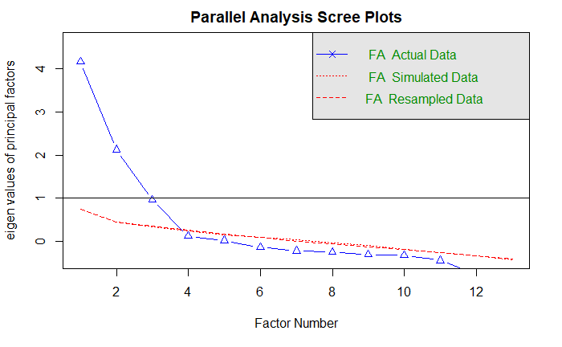

```r
parallel.s6 <- fa.parallel(stsfull_phys, fm = 'pa', fa = 'fa')
```

EFA PAF 3 factors Only phys:

```r
threefactor.pa.full_phys <- fa(stsfull_phys,nfactors = 3,rotate = "oblimin",fm="pa")
print(threefactor.pa.full_phys)
```

```
Factor Analysis using method =  pa
Call: fa(r = stsfull_phys, nfactors = 3, rotate = "oblimin",
    fm = "pa")
Standardized loadings (pattern matrix) based upon correlation matrix
```

|  | PA2 | PA1 | PA3 | h2 | u2 | com |
| --- | --- | --- | --- | --- | --- | --- |
| q0046_0001 | -0.17 | 0.07 | 0.22 | 0.0800254 | 0.9199746 | 2.083591 |
| q0047_0001 | -0.19 | 0.43 | -0.14 | 0.1569661 | 0.8430339 | 1.644278 |
| q0048_0001 | 0.63 | -0.14 | -0.15 | 0.3964372 | 0.6035628 | 1.204227 |
| q0049_0001 | -0.17 | 0.75 | -0.09 | 0.4990717 | 0.5009283 | 1.125368 |
| q0050_0001 | 0.06 | 0.84 | -0.02 | 0.7151756 | 0.2848244 | 1.011380 |
| q0051_0001 | 0.03 | 0.82 | 0.05 | 0.7311170 | 0.2688830 | 1.008889 |
| q0052_0001 | 0.09 | 0.84 | 0.11 | 0.8573862 | 0.1426138 | 1.054448 |
| q0053_0001 | 0.01 | -0.07 | 0.85 | 0.6662735 | 0.3337265 | 1.015312 |
| q0054_0001 | 0.00 | 0.03 | 0.89 | 0.8244675 | 0.1755325 | 1.001704 |
| q0055_0001 | -0.02 | 0.05 | 0.92 | 0.8998958 | 0.1001042 | 1.007124 |

[output cut: 3 more lines]

```
                       PA2  PA1  PA3
SS loadings           2.91 2.90 2.50
Proportion Var        0.22 0.22 0.19
Cumulative Var        0.22 0.45 0.64
Proportion Explained  0.35 0.35 0.30
Cumulative Proportion 0.35 0.70 1.00

 With factor correlations of
     PA2  PA1  PA3
PA2 1.00 0.16 0.18
PA1 0.16 1.00 0.55
PA3 0.18 0.55 1.00

Mean item complexity =  1.2
Test of the hypothesis that 3 factors are sufficient.

The degrees of freedom for the null model are  78  and the objective function was  10.33 with Chi Square of  1258.49
The degrees of freedom for the model are 42  and the objective function was  1.48

The root mean square of the residuals (RMSR) is  0.04
The df corrected root mean square of the residuals is  0.06

The harmonic number of observations is  128 with the empirical chi square  38.89  with prob <  0.61
The total number of observations was  128  with Likelihood Chi Square =  177.46  with prob <  1.4e-18

Tucker Lewis Index of factoring reliability =  0.783
RMSEA index =  0.165  and the 90 % confidence intervals are  0.136 0.184
BIC =  -26.32
Fit based upon off diagonal values = 0.99
Measures of factor score adequacy
                                                   PA2  PA1  PA3
Correlation of (regression) scores with factors   0.97 0.96 0.97
Multiple R square of scores with factors          0.94 0.92 0.94
Minimum correlation of possible factor scores     0.88 0.84 0.88
```

Supress factor loadings below 0.49

```r
print(threefactor.pa.full_phys$loadings,cutoff = 0.49)
```

```
Loadings:
           PA2    PA1    PA3
q0046_0001
q0047_0001
q0048_0001  0.629
q0049_0001         0.754
q0050_0001         0.845
q0051_0001         0.823
q0052_0001         0.843
q0053_0001                0.853
q0054_0001                0.894
q0055_0001                0.921
q0056_0001  0.882
q0057_0001  0.904
q0058_0001  0.915

                 PA2   PA1   PA3
SS loadings    2.931 2.892 2.489
Proportion Var 0.225 0.222 0.191
Cumulative Var 0.225 0.448 0.639
```

EFA PAF 2 factors Only phys:

```r
twofactor.pa.full_phys <- fa(stsfull_phys,nfactors = 2,rotate = "oblimin",fm="pa")
print(twofactor.pa.full_phys)
```

```
Factor Analysis using method =  pa
Call: fa(r = stsfull_phys, nfactors = 2, rotate = "oblimin",
    fm = "pa")
Standardized loadings (pattern matrix) based upon correlation matrix
```

|  | PA1 | PA2 | h2 | u2 | com |
| --- | --- | --- | --- | --- | --- |
| q0046_0001 | 0.25 | -0.16 | 0.07280739 | 0.9271926 | 1.727416 |
| q0047_0001 | 0.27 | -0.21 | 0.09538190 | 0.9046181 | 1.884026 |
| q0048_0001 | -0.25 | 0.63 | 0.39404150 | 0.6059585 | 1.305736 |
| q0049_0001 | 0.61 | -0.19 | 0.36558898 | 0.6344110 | 1.195829 |
| q0050_0001 | 0.75 | 0.02 | 0.56930630 | 0.4306937 | 1.001960 |
| q0051_0001 | 0.79 | -0.01 | 0.62960931 | 0.3703907 | 1.000107 |
| q0052_0001 | 0.87 | 0.05 | 0.77434895 | 0.2256510 | 1.007061 |
| q0053_0001 | 0.62 | 0.04 | 0.39340097 | 0.6065990 | 1.008651 |
| q0054_0001 | 0.74 | 0.03 | 0.55672923 | 0.4432708 | 1.003358 |
| q0055_0001 | 0.78 | 0.02 | 0.62077109 | 0.3792289 | 1.001001 |

[output cut: 3 more lines]

```
                       PA1  PA2
SS loadings           4.04 2.90
Proportion Var        0.31 0.22
Cumulative Var        0.31 0.53
Proportion Explained  0.58 0.42
Cumulative Proportion 0.58 1.00

 With factor correlations of
    PA1 PA2
PA1 1.0 0.2
PA2 0.2 1.0

Mean item complexity =  1.2
Test of the hypothesis that 2 factors are sufficient.

The degrees of freedom for the null model are  78  and the objective function was  10.33 with Chi Square of  1258.49
The degrees of freedom for the model are 53  and the objective function was  3.42

The root mean square of the residuals (RMSR) is  0.1
The df corrected root mean square of the residuals is  0.12

The harmonic number of observations is  128 with the empirical chi square  187.53  with prob <  6.4e-17
The total number of observations was  128  with Likelihood Chi Square =  412.4  with prob <  4.2e-57

Tucker Lewis Index of factoring reliability =  0.547
RMSEA index =  0.238  and the 90 % confidence intervals are  0.211 0.252
BIC =  155.24
Fit based upon off diagonal values = 0.93
Measures of factor score adequacy
                                                   PA1  PA2
Correlation of (regression) scores with factors   0.96 0.97
Multiple R square of scores with factors          0.92 0.94
Minimum correlation of possible factor scores     0.84 0.88
```

Supress factor loadings below 0.49

```r
print(twofactor.pa.full_phys$loadings,cutoff = 0.49)
```

```
Loadings:
           PA1    PA2
q0046_0001
q0047_0001
q0048_0001         0.628
q0049_0001  0.613
q0050_0001  0.750
q0051_0001  0.795
q0052_0001  0.868
q0053_0001  0.618
q0054_0001  0.740
q0055_0001  0.784
q0056_0001         0.886
q0057_0001         0.898
q0058_0001         0.913

                 PA1   PA2
SS loadings    4.075 2.932
Proportion Var 0.313 0.226
Cumulative Var 0.313 0.539
```

EFA PAF 1 factors Only phys:

```r
onefactor.pa.full_phys <- fa(stsfull_phys,nfactors = 1,rotate = "oblimin",fm="pa")
print(onefactor.pa.full_phys)
```

```
Factor Analysis using method =  pa
Call: fa(r = stsfull_phys, nfactors = 1, rotate = "oblimin",
    fm = "pa")
Standardized loadings (pattern matrix) based upon correlation matrix
```

|  | PA1 | h2 | u2 | com |
| --- | --- | --- | --- | --- |
| q0046_0001 | 0.18 | 3.336568e-02 | 0.9666343 | 1 |
| q0047_0001 | 0.18 | 3.342745e-02 | 0.9665725 | 1 |
| q0048_0001 | 0.00 | 8.609180e-07 | 0.9999991 | 1 |
| q0049_0001 | 0.52 | 2.673149e-01 | 0.7326851 | 1 |
| q0050_0001 | 0.75 | 5.595290e-01 | 0.4404710 | 1 |
| q0051_0001 | 0.78 | 6.052496e-01 | 0.3947504 | 1 |
| q0052_0001 | 0.88 | 7.695434e-01 | 0.2304566 | 1 |
| q0053_0001 | 0.63 | 3.952110e-01 | 0.6047890 | 1 |
| q0054_0001 | 0.74 | 5.531831e-01 | 0.4468169 | 1 |
| q0055_0001 | 0.78 | 6.118767e-01 | 0.3881233 | 1 |

[output cut: 3 more lines]

```
                PA1
SS loadings    4.16
Proportion Var 0.32

Mean item complexity =  1
Test of the hypothesis that 1 factor is sufficient.

The degrees of freedom for the null model are  78  and the objective function was  10.33 with Chi Square of  1258.49
The degrees of freedom for the model are 65  and the objective function was  6.53

The root mean square of the residuals (RMSR) is  0.21
The df corrected root mean square of the residuals is  0.24

The harmonic number of observations is  128 with the empirical chi square  922.74  with prob <  8.2e-152
The total number of observations was  128  with Likelihood Chi Square =  791.41  with prob <  2.2e-125

Tucker Lewis Index of factoring reliability =  0.257
RMSEA index =  0.304  and the 90 % confidence intervals are  0.278 0.315
BIC =  476.03
Fit based upon off diagonal values = 0.68
Measures of factor score adequacy
                                                   PA1
Correlation of (regression) scores with factors   0.96
Multiple R square of scores with factors          0.92
Minimum correlation of possible factor scores     0.83
```

Supress factor loadings below 0.49

```r
print(onefactor.pa.full_phys$loadings,cutoff = 0.49)
```

```
Loadings:
           PA1
q0046_0001
q0047_0001
q0048_0001
q0049_0001  0.517
q0050_0001  0.748
q0051_0001  0.778
q0052_0001  0.877
q0053_0001  0.629
q0054_0001  0.744
q0055_0001  0.782
q0056_0001
q0057_0001
q0058_0001

                 PA1
SS loadings    4.157
Proportion Var 0.320
```

Alpha on final Phys scale:

```r
stsfull_phys_final <-dplyr::select(surveyfull, q0048_0001, q0049_0001, q0050_0001, q0051_0001, q0052_0001, q0053_0001, q0054_0001, q0055_0001, q0056_0001, q0057_0001, q0058_0001)
```

```r
alpha_phys_final <- psych::alpha(stsfull_phys_final)
alpha_phys_final
```

```
Reliability analysis
Call: psych::alpha(x = stsfull_phys_final)
```

|  | raw_alpha | std.alpha | G6(smc) | average_r | S/N | ase | mean | sd | median_r |
| --- | --- | --- | --- | --- | --- | --- | --- | --- | --- |
|  | 0.8208977 | 0.8411737 | 0.9379722 | 0.3249954 | 5.296186 | 0.02400049 | 0.9225852 | 0.6987136 | 0.2601012 |

```
 lower alpha upper     95% confidence boundaries
0.77 0.82 0.87

 Reliability if an item is dropped:
```

|  | raw_alpha | std.alpha | G6(smc) | average_r | S/N | alpha se | var.r | med.r |
| --- | --- | --- | --- | --- | --- | --- | --- | --- |
| q0048_0001 | 0.8368552 | 0.8587155 | 0.9403646 | 0.3780288 | 6.077915 | 0.02244472 | 0.06981841 | 0.2844119 |
| q0049_0001 | 0.8240959 | 0.8423445 | 0.9418509 | 0.3482345 | 5.342943 | 0.02345782 | 0.08621460 | 0.2601012 |
| q0050_0001 | 0.8000206 | 0.8198281 | 0.9274749 | 0.3127268 | 4.550256 | 0.02637140 | 0.08950028 | 0.2102235 |
| q0051_0001 | 0.7998020 | 0.8187297 | 0.9276173 | 0.3111346 | 4.516623 | 0.02629990 | 0.08842529 | 0.2172517 |
| q0052_0001 | 0.7915696 | 0.8105859 | 0.9182336 | 0.2996923 | 4.279437 | 0.02737364 | 0.08571599 | 0.2058846 |
| q0053_0001 | 0.8131159 | 0.8284301 | 0.9333059 | 0.3256242 | 4.828527 | 0.02509507 | 0.09021070 | 0.2601012 |
| q0054_0001 | 0.8107438 | 0.8205761 | 0.9248651 | 0.3138180 | 4.573392 | 0.02550592 | 0.08756241 | 0.2172517 |
| q0055_0001 | 0.8084726 | 0.8179409 | 0.9199605 | 0.3099985 | 4.492721 | 0.02564193 | 0.08534835 | 0.2172517 |
| q0056_0001 | 0.7973625 | 0.8320654 | 0.9256163 | 0.3313138 | 4.954699 | 0.02735851 | 0.08620600 | 0.2844119 |
| q0057_0001 | 0.7921112 | 0.8276620 | 0.9219140 | 0.3244407 | 4.802549 | 0.02844314 | 0.08750328 | 0.2844119 |

[output cut: 1 more lines]

```
 Item statistics
```

|  | n | raw.r | std.r | r.cor | r.drop | mean | sd |
| --- | --- | --- | --- | --- | --- | --- | --- |
| q0048_0001 | 128 | 0.3966801 | 0.2725397 | 0.2130491 | 0.2229914 | 1.7578125 | 1.4349194 |
| q0049_0001 | 128 | 0.4077918 | 0.4686302 | 0.3986703 | 0.2797649 | 0.6015625 | 1.0892448 |
| q0050_0001 | 128 | 0.6547189 | 0.7023236 | 0.6852848 | 0.5603229 | 0.6718750 | 1.1019623 |
| q0051_0001 | 128 | 0.6570464 | 0.7128033 | 0.6926712 | 0.5595662 | 0.7421875 | 1.1380747 |
| q0052_0001 | 128 | 0.7298889 | 0.7881104 | 0.7892284 | 0.6493232 | 0.7421875 | 1.1241521 |
| q0053_0001 | 128 | 0.5059539 | 0.6174401 | 0.5843727 | 0.4141824 | 0.3359375 | 0.8719364 |
| q0054_0001 | 128 | 0.5720686 | 0.6951426 | 0.6865694 | 0.5145426 | 0.2187500 | 0.6139776 |
| q0055_0001 | 128 | 0.5946415 | 0.7202804 | 0.7192964 | 0.5331888 | 0.2500000 | 0.6757906 |
| q0056_0001 | 128 | 0.6957183 | 0.5799935 | 0.5623756 | 0.5780773 | 1.7812500 | 1.4359693 |
| q0057_0001 | 128 | 0.7324544 | 0.6252292 | 0.6285234 | 0.6224043 | 1.5312500 | 1.4685013 |

[output cut: 1 more lines]

```
Non missing response frequency for each item
              0    1    2    3 miss
q0048_0001 0.38 0.02 0.05 0.55    0
q0049_0001 0.73 0.06 0.07 0.13    0
q0050_0001 0.69 0.09 0.09 0.13    0
q0051_0001 0.63 0.16 0.03 0.17    0
q0052_0001 0.64 0.12 0.09 0.15    0
q0053_0001 0.85 0.04 0.03 0.08    0
q0054_0001 0.86 0.09 0.03 0.02    0
q0055_0001 0.86 0.05 0.06 0.02    0
q0056_0001 0.38 0.03 0.03 0.56    0
q0057_0001 0.46 0.03 0.02 0.48    0
q0058_0001 0.47 0.02 0.03 0.48    0
```

Alpha on final Psych scale:

```r
stsfull_psych_final <- dplyr::select(surveyfull, q0059_0001, q0060_0001, q0061_0001, q0062_0001, q0064_0001, q0065_0001, q0066_0001, q0067_0001, q0068_0001, q0069_0001, q0070_0001, q0071_0001, q0072_0001, q0074_0001, q0077_0001, q0081_0001, q0082_0001, q0083_0001, q0084_0001, q0085_0001, q0087_0001, q0088_0001, q0089_0001, q0090_0001)
```

```r
alpha_psych_final <- psych::alpha(stsfull_psych_final)
alpha_psych_final
```

```
Reliability analysis
Call: psych::alpha(x = stsfull_psych_final)
```

|  | raw_alpha | std.alpha | G6(smc) | average_r | S/N | ase | mean | sd | median_r |
| --- | --- | --- | --- | --- | --- | --- | --- | --- | --- |
|  | 0.9160843 | 0.9164643 | 0.9560074 | 0.3137157 | 10.97093 | 0.01050842 | 0.7070312 | 0.5336946 | 0.3080623 |

```
 lower alpha upper     95% confidence boundaries
0.9 0.92 0.94

 Reliability if an item is dropped:
```

|  | raw_alpha | std.alpha | G6(smc) | average_r | S/N | alpha se | var.r | med.r |
| --- | --- | --- | --- | --- | --- | --- | --- | --- |
| q0059_0001 | 0.9142860 | 0.9143205 | 0.9517312 | 0.3169277 | 10.67140 | 0.01069544 | 0.02953288 | 0.3075087 |
| q0060_0001 | 0.9158083 | 0.9162775 | 0.9521153 | 0.3224179 | 10.94423 | 0.01052485 | 0.02851931 | 0.3195700 |
| q0061_0001 | 0.9123213 | 0.9126720 | 0.9542897 | 0.3124288 | 10.45108 | 0.01100745 | 0.03127684 | 0.3043940 |
| q0062_0001 | 0.9150960 | 0.9153108 | 0.9561566 | 0.3196854 | 10.80789 | 0.01063561 | 0.03105216 | 0.3259443 |
| q0064_0001 | 0.9145426 | 0.9147154 | 0.9554138 | 0.3180223 | 10.72544 | 0.01070768 | 0.03115418 | 0.3214264 |
| q0065_0001 | 0.9137752 | 0.9137228 | 0.9540268 | 0.3152836 | 10.59055 | 0.01076686 | 0.03039543 | 0.3053620 |
| q0066_0001 | 0.9128780 | 0.9136552 | 0.9523339 | 0.3150986 | 10.58148 | 0.01088736 | 0.02954268 | 0.3116545 |
| q0067_0001 | 0.9128292 | 0.9128937 | 0.9531292 | 0.3130273 | 10.48022 | 0.01089716 | 0.02905562 | 0.3116545 |
| q0068_0001 | 0.9125984 | 0.9135749 | 0.9535677 | 0.3148789 | 10.57071 | 0.01094896 | 0.02844440 | 0.3116545 |
| q0069_0001 | 0.9112120 | 0.9113002 | 0.9523161 | 0.3087694 | 10.27399 | 0.01110510 | 0.02985834 | 0.3043940 |

[output cut: 14 more lines]

```
 Item statistics
```

|  | n | raw.r | std.r | r.cor | r.drop | mean | sd |
| --- | --- | --- | --- | --- | --- | --- | --- |
| q0059_0001 | 128 | 0.5059399 | 0.5272018 | 0.5198218 | 0.4512693 | 0.5703125 | 0.8934018 |
| q0060_0001 | 128 | 0.4443576 | 0.4282806 | 0.4194980 | 0.3808789 | 0.6171875 | 0.9649046 |
| q0061_0001 | 128 | 0.6267790 | 0.6082602 | 0.5852720 | 0.5676975 | 1.2968750 | 1.1457513 |
| q0062_0001 | 128 | 0.4705544 | 0.4775139 | 0.4400503 | 0.4113803 | 0.9765625 | 0.9261285 |
| q0064_0001 | 128 | 0.5170341 | 0.5074793 | 0.4754986 | 0.4543575 | 1.1796875 | 1.0305078 |
| q0065_0001 | 128 | 0.5464721 | 0.5568244 | 0.5366126 | 0.4878045 | 0.9296875 | 1.0053682 |
| q0066_0001 | 128 | 0.5842955 | 0.5601573 | 0.5504341 | 0.5299595 | 1.0156250 | 0.9879939 |
| q0067_0001 | 128 | 0.5783217 | 0.5974770 | 0.5864474 | 0.5337605 | 0.4531250 | 0.8119130 |
| q0068_0001 | 128 | 0.5927644 | 0.5641156 | 0.5526666 | 0.5423662 | 0.6640625 | 0.9330109 |
| q0069_0001 | 128 | 0.6581772 | 0.6741950 | 0.6646049 | 0.6143752 | 0.6796875 | 0.9216007 |

[output cut: 14 more lines]

```
Non missing response frequency for each item
              0    1    2    3 miss
q0059_0001 0.65 0.19 0.11 0.05    0
q0060_0001 0.64 0.19 0.09 0.09    0
q0061_0001 0.34 0.22 0.23 0.20    0
q0062_0001 0.38 0.34 0.23 0.06    0
q0064_0001 0.34 0.27 0.28 0.12    0
q0065_0001 0.44 0.30 0.16 0.10    0
q0066_0001 0.37 0.36 0.16 0.11    0
q0067_0001 0.72 0.14 0.11 0.03    0
q0068_0001 0.59 0.23 0.11 0.07    0
q0069_0001 0.59 0.17 0.20 0.04    0
q0070_0001 0.45 0.25 0.21 0.09    0
q0071_0001 0.62 0.19 0.13 0.05    0
q0072_0001 0.42 0.25 0.19 0.14    0
q0074_0001 0.80 0.13 0.05 0.02    0
q0077_0001 0.41 0.20 0.23 0.16    0
q0081_0001 0.72 0.18 0.07 0.03    0
q0082_0001 0.62 0.21 0.11 0.05    0
q0083_0001 0.93 0.03 0.02 0.02    0
q0084_0001 0.77 0.09 0.08 0.06    0
q0085_0001 0.36 0.27 0.21 0.16    0
q0087_0001 0.76 0.15 0.05 0.04    0
q0088_0001 0.89 0.10 0.00 0.01    0
q0089_0001 0.57 0.20 0.15 0.08    0
q0090_0001 0.61 0.23 0.14 0.02    0
```

ITC on final Phys scale:

```r
item.total(stsfull_phys_final)
```

| Variable | Item.Total | Alpha.Without | N |
| --- | --- | --- | --- |
| q0048_0001 | 0.2229914 | 0.8368552 | 128 |
| q0049_0001 | 0.2797649 | 0.8240959 | 128 |
| q0050_0001 | 0.5603229 | 0.8000206 | 128 |
| q0051_0001 | 0.5595662 | 0.7998020 | 128 |
| q0052_0001 | 0.6493232 | 0.7915696 | 128 |
| q0053_0001 | 0.4141824 | 0.8131159 | 128 |
| q0054_0001 | 0.5145426 | 0.8107438 | 128 |
| q0055_0001 | 0.5331888 | 0.8084726 | 128 |
| q0056_0001 | 0.5780773 | 0.7973625 | 128 |
| q0057_0001 | 0.6224043 | 0.7921112 | 128 |

[output cut: 1 more lines]

ITC on final Psych scale:

```r
item.total(stsfull_psych_final)
```

| Variable | Item.Total | Alpha.Without | N |
| --- | --- | --- | --- |
| q0059_0001 | 0.4512693 | 0.9142860 | 128 |
| q0060_0001 | 0.3808789 | 0.9158083 | 128 |
| q0061_0001 | 0.5676975 | 0.9123213 | 128 |
| q0062_0001 | 0.4113803 | 0.9150960 | 128 |
| q0064_0001 | 0.4543575 | 0.9145426 | 128 |
| q0065_0001 | 0.4878045 | 0.9137752 | 128 |
| q0066_0001 | 0.5299595 | 0.9128780 | 128 |
| q0067_0001 | 0.5337605 | 0.9128292 | 128 |
| q0068_0001 | 0.5423662 | 0.9125984 | 128 |
| q0069_0001 | 0.6143752 | 0.9112120 | 128 |

[output cut: 14 more lines]

Create full final STS scale (final STS phys + final STS psych)

```r
stsfull_final <- cbind(stsfull_phys_final, stsfull_psych_final)
```

create totals:

```r
stsfull_final.tot <- stsfull_final
stsfull_phys_final.tot <- stsfull_phys_final
stsfull_psych_final.tot <- stsfull_psych_final
```

```r
stsfull_final.tot <- cbind(stsfull_final.tot, total = rowSums(stsfull_final.tot))
stsfull_phys_final.tot <- cbind(stsfull_phys_final.tot, total = rowSums(stsfull_phys_final.tot))
stsfull_psych_final.tot <- cbind(stsfull_psych_final.tot, total = rowSums(stsfull_psych_final.tot))
```

Descriptive stats of scale and subscale totals

```r
describe(stsfull_final.tot)
```

|  | vars | n | mean | sd | median | trimmed | mad | min | max | range | skew | kurtosis | se |
| --- | --- | --- | --- | --- | --- | --- | --- | --- | --- | --- | --- | --- | --- |
| q0048_0001 | 1 | 128 | 1.76 | 1.43 | 3 | 1.82 | 0.00 | 0 | 3 | 3 | -0.35 | -1.83 | 0.13 |
| q0049_0001 | 2 | 128 | 0.60 | 1.09 | 0 | 0.39 | 0.00 | 0 | 3 | 3 | 1.45 | 0.38 | 0.10 |
| q0050_0001 | 3 | 128 | 0.67 | 1.10 | 0 | 0.48 | 0.00 | 0 | 3 | 3 | 1.26 | -0.06 | 0.10 |
| q0051_0001 | 4 | 128 | 0.74 | 1.14 | 0 | 0.57 | 0.00 | 0 | 3 | 3 | 1.21 | -0.18 | 0.10 |
| q0052_0001 | 5 | 128 | 0.74 | 1.12 | 0 | 0.57 | 0.00 | 0 | 3 | 3 | 1.14 | -0.33 | 0.10 |
| q0053_0001 | 6 | 128 | 0.34 | 0.87 | 0 | 0.09 | 0.00 | 0 | 3 | 3 | 2.41 | 4.25 | 0.08 |
| q0054_0001 | 7 | 128 | 0.22 | 0.61 | 0 | 0.06 | 0.00 | 0 | 3 | 3 | 3.08 | 9.32 | 0.05 |
| q0055_0001 | 8 | 128 | 0.25 | 0.68 | 0 | 0.06 | 0.00 | 0 | 3 | 3 | 2.70 | 6.34 | 0.06 |
| q0056_0001 | 9 | 128 | 1.78 | 1.44 | 3 | 1.85 | 0.00 | 0 | 3 | 3 | -0.38 | -1.82 | 0.13 |
| q0057_0001 | 10 | 128 | 1.53 | 1.47 | 2 | 1.54 | 1.48 | 0 | 3 | 3 | -0.04 | -1.97 | 0.13 |

[output cut: 26 more lines]

```r
describe(stsfull_phys_final.tot)
```

|  | vars | n | mean | sd | median | trimmed | mad | min | max | range | skew | kurtosis | se |
| --- | --- | --- | --- | --- | --- | --- | --- | --- | --- | --- | --- | --- | --- |
| q0048_0001 | 1 | 128 | 1.76 | 1.43 | 3 | 1.82 | 0.00 | 0 | 3 | 3 | -0.35 | -1.83 | 0.13 |
| q0049_0001 | 2 | 128 | 0.60 | 1.09 | 0 | 0.39 | 0.00 | 0 | 3 | 3 | 1.45 | 0.38 | 0.10 |
| q0050_0001 | 3 | 128 | 0.67 | 1.10 | 0 | 0.48 | 0.00 | 0 | 3 | 3 | 1.26 | -0.06 | 0.10 |
| q0051_0001 | 4 | 128 | 0.74 | 1.14 | 0 | 0.57 | 0.00 | 0 | 3 | 3 | 1.21 | -0.18 | 0.10 |
| q0052_0001 | 5 | 128 | 0.74 | 1.12 | 0 | 0.57 | 0.00 | 0 | 3 | 3 | 1.14 | -0.33 | 0.10 |
| q0053_0001 | 6 | 128 | 0.34 | 0.87 | 0 | 0.09 | 0.00 | 0 | 3 | 3 | 2.41 | 4.25 | 0.08 |
| q0054_0001 | 7 | 128 | 0.22 | 0.61 | 0 | 0.06 | 0.00 | 0 | 3 | 3 | 3.08 | 9.32 | 0.05 |
| q0055_0001 | 8 | 128 | 0.25 | 0.68 | 0 | 0.06 | 0.00 | 0 | 3 | 3 | 2.70 | 6.34 | 0.06 |
| q0056_0001 | 9 | 128 | 1.78 | 1.44 | 3 | 1.85 | 0.00 | 0 | 3 | 3 | -0.38 | -1.82 | 0.13 |
| q0057_0001 | 10 | 128 | 1.53 | 1.47 | 2 | 1.54 | 1.48 | 0 | 3 | 3 | -0.04 | -1.97 | 0.13 |

[output cut: 2 more lines]

```r
describe(stsfull_psych_final.tot)
```

|  | vars | n | mean | sd | median | trimmed | mad | min | max | range | skew | kurtosis | se |
| --- | --- | --- | --- | --- | --- | --- | --- | --- | --- | --- | --- | --- | --- |
| q0059_0001 | 1 | 128 | 0.57 | 0.89 | 0 | 0.40 | 0.00 | 0 | 3 | 3 | 1.40 | 0.83 | 0.08 |
| q0060_0001 | 2 | 128 | 0.62 | 0.96 | 0 | 0.42 | 0.00 | 0 | 3 | 3 | 1.39 | 0.67 | 0.09 |
| q0061_0001 | 3 | 128 | 1.30 | 1.15 | 1 | 1.25 | 1.48 | 0 | 3 | 3 | 0.22 | -1.41 | 0.10 |
| q0062_0001 | 4 | 128 | 0.98 | 0.93 | 1 | 0.89 | 1.48 | 0 | 3 | 3 | 0.52 | -0.77 | 0.08 |
| q0064_0001 | 5 | 128 | 1.18 | 1.03 | 1 | 1.11 | 1.48 | 0 | 3 | 3 | 0.28 | -1.17 | 0.09 |
| q0065_0001 | 6 | 128 | 0.93 | 1.01 | 1 | 0.80 | 1.48 | 0 | 3 | 3 | 0.74 | -0.64 | 0.09 |
| q0066_0001 | 7 | 128 | 1.02 | 0.99 | 1 | 0.90 | 1.48 | 0 | 3 | 3 | 0.65 | -0.65 | 0.09 |
| q0067_0001 | 8 | 128 | 0.45 | 0.81 | 0 | 0.29 | 0.00 | 0 | 3 | 3 | 1.64 | 1.57 | 0.07 |
| q0068_0001 | 9 | 128 | 0.66 | 0.93 | 0 | 0.50 | 0.00 | 0 | 3 | 3 | 1.22 | 0.38 | 0.08 |
| q0069_0001 | 10 | 128 | 0.68 | 0.92 | 0 | 0.56 | 0.00 | 0 | 3 | 3 | 0.97 | -0.43 | 0.08 |

[output cut: 15 more lines]

Histograms of full scale and subscale totals:

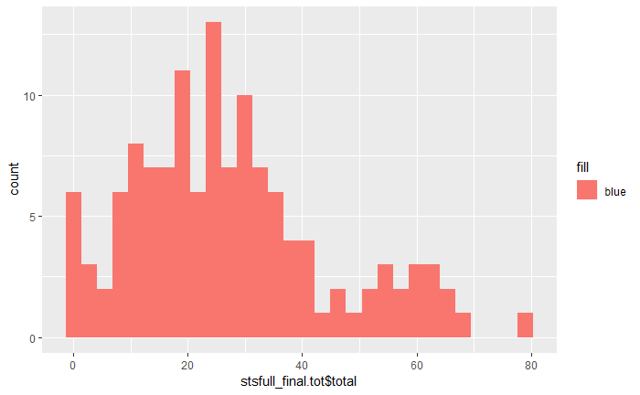

```r
ggplot(data=stsfull_final.tot, aes(stsfull_final.tot$total, fill = "blue")) +
  geom_histogram()
```

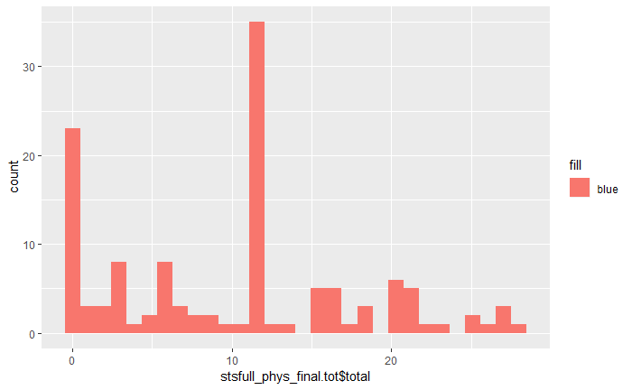

```r
ggplot(data=stsfull_phys_final.tot, aes(stsfull_phys_final.tot$total, fill = "blue")) +
  geom_histogram()
```

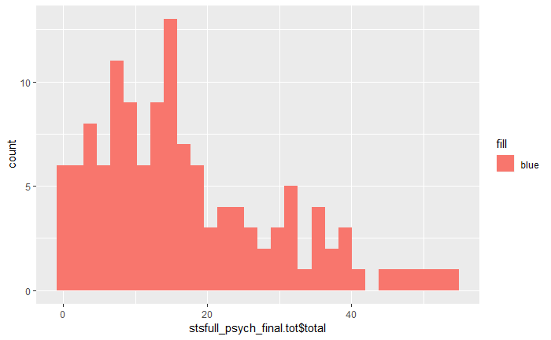

```r
ggplot(data=stsfull_psych_final.tot, aes(stsfull_psych_final.tot$total, fill = "blue")) +
  geom_histogram()
```

Rerun 4 factor psych sep scale on 24 items that loaded: EFA PAF 4 factors Only psych Items that loaded

Create scale of 24 items that loaded

```r
stsfull_psych_loaded <- dplyr::select(surveyfull, q0059_0001, q0060_0001, q0061_0001, q0062_0001, q0064_0001, q0065_0001, q0066_0001, q0067_0001, q0068_0001, q0069_0001, q0070_0001, q0071_0001, q0072_0001, q0074_0001, q0077_0001, q0081_0001, q0082_0001, q0083_0001, q0084_0001, q0085_0001, q0087_0001, q0088_0001, q0089_0001, q0090_0001)
```

Trial analysis on survey (psych only) items that loaded: Using PA

```
Parallel analysis suggests that the number of factors =  5  and the number of components =  NA
```

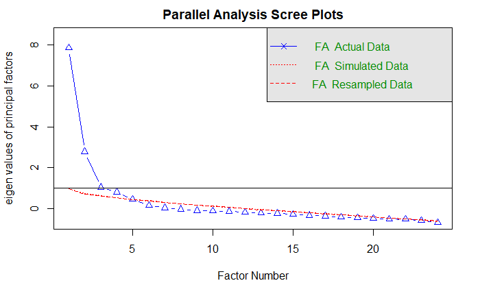

```r
parallel.s7 <- fa.parallel(stsfull_psych_loaded, fm = 'pa', fa = 'fa')
```

EFA PAF 4 factors Only psych Items that previosly loaded

```r
fourfactor.pa.full_psych_loaded <- fa(stsfull_psych_loaded,nfactors = 4,rotate = "oblimin",fm="pa")
print(fourfactor.pa.full_psych_loaded)
```

```
Factor Analysis using method =  pa
Call: fa(r = stsfull_psych_loaded, nfactors = 4, rotate = "oblimin",
    fm = "pa")
Standardized loadings (pattern matrix) based upon correlation matrix
```

|  | PA1 | PA2 | PA3 | PA4 | h2 | u2 | com |
| --- | --- | --- | --- | --- | --- | --- | --- |
| q0059_0001 | 0.71 | -0.07 | -0.07 | 0.16 | 0.4692016 | 0.5307984 | 1.143871 |
| q0060_0001 | 0.00 | 0.14 | 0.06 | 0.62 | 0.4780578 | 0.5219422 | 1.121893 |
| q0061_0001 | 0.02 | 0.13 | 0.47 | 0.27 | 0.4319601 | 0.5680399 | 1.767242 |
| q0062_0001 | 0.14 | -0.05 | 0.43 | 0.09 | 0.2584236 | 0.7415764 | 1.325599 |
| q0064_0001 | -0.01 | 0.06 | 0.49 | 0.16 | 0.3103138 | 0.6896862 | 1.251245 |
| q0065_0001 | 0.50 | -0.14 | 0.24 | 0.18 | 0.4027412 | 0.5972588 | 1.924817 |
| q0066_0001 | -0.11 | 0.17 | 0.34 | 0.62 | 0.6606017 | 0.3393983 | 1.824267 |
| q0067_0001 | 0.73 | 0.08 | 0.00 | -0.04 | 0.5671317 | 0.4328683 | 1.028401 |
| q0068_0001 | -0.03 | 0.78 | -0.02 | 0.08 | 0.6275421 | 0.3724579 | 1.026131 |
| q0069_0001 | 0.60 | 0.17 | 0.13 | -0.04 | 0.5516708 | 0.4483292 | 1.273016 |

[output cut: 14 more lines]

```
                       PA1  PA2  PA3  PA4
SS loadings           4.43 3.99 3.18 1.96
Proportion Var        0.18 0.17 0.13 0.08
Cumulative Var        0.18 0.35 0.48 0.57
Proportion Explained  0.33 0.29 0.23 0.14
Cumulative Proportion 0.33 0.62 0.86 1.00

 With factor correlations of
     PA1  PA2  PA3  PA4
PA1 1.00 0.28 0.46 0.02
PA2 0.28 1.00 0.37 0.34
PA3 0.46 0.37 1.00 0.14
PA4 0.02 0.34 0.14 1.00

Mean item complexity =  1.4
Test of the hypothesis that 4 factors are sufficient.

The degrees of freedom for the null model are  276  and the objective function was  16.51 with Chi Square of  1951.23
The degrees of freedom for the model are 186  and the objective function was  3.35

The root mean square of the residuals (RMSR) is  0.05
The df corrected root mean square of the residuals is  0.06

The harmonic number of observations is  128 with the empirical chi square  151.7  with prob <  0.97
The total number of observations was  128  with Likelihood Chi Square =  386.58  with prob <  3.7e-16

Tucker Lewis Index of factoring reliability =  0.818
RMSEA index =  0.101  and the 90 % confidence intervals are  0.079 0.105
BIC =  -515.9
Fit based upon off diagonal values = 0.98
Measures of factor score adequacy
                                                   PA1  PA2  PA3
Correlation of (regression) scores with factors   0.96 0.96 0.92
Multiple R square of scores with factors          0.92 0.93 0.85
Minimum correlation of possible factor scores     0.84 0.86 0.71
                                                   PA4
Correlation of (regression) scores with factors   0.91
Multiple R square of scores with factors          0.83
Minimum correlation of possible factor scores     0.66
```

Supress factor loadings below 0.49

```r
print(fourfactor.pa.full_psych_loaded$loadings,cutoff = 0.49)
```

```
Loadings:
           PA1    PA2    PA3    PA4
q0059_0001  0.711
q0060_0001                       0.616
q0061_0001
q0062_0001
q0064_0001
q0065_0001  0.498
q0066_0001                       0.615
q0067_0001  0.728
q0068_0001         0.779
q0069_0001  0.602
q0070_0001         0.875
q0071_0001  0.719
q0072_0001         0.781
q0074_0001  0.643
q0077_0001         0.829
q0081_0001  0.835
q0082_0001         0.678
q0083_0001  0.675
q0084_0001                       0.698
q0085_0001                0.537
q0087_0001                0.648
q0088_0001                0.673
q0089_0001                0.588
q0090_0001                0.516

                 PA1   PA2   PA3   PA4
SS loadings    4.048 3.616 2.675 1.752
Proportion Var 0.169 0.151 0.111 0.073
Cumulative Var 0.169 0.319 0.431 0.504
```

Rerun 3 factor phys sep scale on 11 items that loaded: EFA PAF 3 factors Only phys Items that previously loaded

Create scale of 11 items that loaded:

```r
stsfull_phys_loaded <-dplyr::select(surveyfull, q0048_0001, q0049_0001, q0050_0001, q0051_0001, q0052_0001, q0053_0001, q0054_0001, q0055_0001, q0056_0001, q0057_0001, q0058_0001)
```

Trial analysis on survey full (phys only): Using PA

```
Parallel analysis suggests that the number of factors =  3  and the number of components =  NA
```

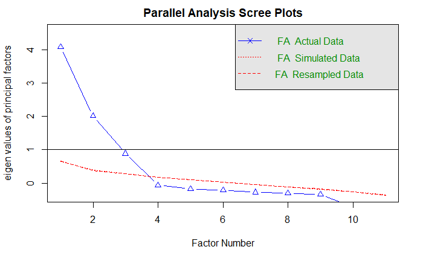

```r
parallel.s8 <- fa.parallel(stsfull_phys_loaded, fm = 'pa', fa = 'fa')
```

EFA PAF 3 factors Only phys Items that previously loaded

```r
threefactor.pa.full_phys_loaded <- fa(stsfull_phys_loaded,nfactors = 3,rotate = "oblimin",fm="pa")
print(threefactor.pa.full_phys_loaded)
```

```
Factor Analysis using method =  pa
Call: fa(r = stsfull_phys_loaded, nfactors = 3, rotate = "oblimin",
    fm = "pa")
Standardized loadings (pattern matrix) based upon correlation matrix
```

|  | PA2 | PA1 | PA3 | h2 | u2 | com |
| --- | --- | --- | --- | --- | --- | --- |
| q0048_0001 | 0.64 | -0.15 | -0.14 | 0.4137084 | 0.58629163 | 1.204174 |
| q0049_0001 | -0.17 | 0.69 | -0.05 | 0.4319151 | 0.56808490 | 1.130278 |
| q0050_0001 | 0.03 | 0.87 | -0.04 | 0.7346425 | 0.26535754 | 1.006051 |
| q0051_0001 | 0.01 | 0.85 | 0.02 | 0.7432967 | 0.25670329 | 1.000786 |
| q0052_0001 | 0.06 | 0.89 | 0.07 | 0.8873630 | 0.11263700 | 1.021007 |
| q0053_0001 | 0.01 | -0.07 | 0.85 | 0.6634246 | 0.33657544 | 1.012638 |
| q0054_0001 | 0.01 | 0.01 | 0.90 | 0.8203181 | 0.17968189 | 1.000632 |
| q0055_0001 | -0.01 | 0.04 | 0.94 | 0.9194480 | 0.08055198 | 1.003993 |
| q0056_0001 | 0.89 | -0.03 | -0.01 | 0.7843140 | 0.21568603 | 1.002734 |
| q0057_0001 | 0.89 | 0.06 | 0.01 | 0.8132479 | 0.18675214 | 1.007938 |

[output cut: 1 more lines]

```
                       PA2  PA1  PA3
SS loadings           2.84 2.79 2.44
Proportion Var        0.26 0.25 0.22
Cumulative Var        0.26 0.51 0.73
Proportion Explained  0.35 0.35 0.30
Cumulative Proportion 0.35 0.70 1.00

 With factor correlations of
     PA2  PA1  PA3
PA2 1.00 0.18 0.17
PA1 0.18 1.00 0.57
PA3 0.17 0.57 1.00

Mean item complexity =  1
Test of the hypothesis that 3 factors are sufficient.

The degrees of freedom for the null model are  55  and the objective function was  9.79 with Chi Square of  1199.2
The degrees of freedom for the model are 25  and the objective function was  1.15

The root mean square of the residuals (RMSR) is  0.04
The df corrected root mean square of the residuals is  0.05

The harmonic number of observations is  128 with the empirical chi square  17.86  with prob <  0.85
The total number of observations was  128  with Likelihood Chi Square =  138.13  with prob <  1.3e-17

Tucker Lewis Index of factoring reliability =  0.779
RMSEA index =  0.195  and the 90 % confidence intervals are  0.159 0.22
BIC =  16.83
Fit based upon off diagonal values = 0.99
Measures of factor score adequacy
                                                   PA2  PA1  PA3
Correlation of (regression) scores with factors   0.97 0.97 0.97
Multiple R square of scores with factors          0.94 0.93 0.95
Minimum correlation of possible factor scores     0.87 0.86 0.90
```

Supress factor loadings below 0.49

```r
print(threefactor.pa.full_phys_loaded$loadings,cutoff = 0.49)
```

```
Loadings:
           PA2    PA1    PA3
q0048_0001  0.644
q0049_0001         0.693
q0050_0001         0.872
q0051_0001         0.852
q0052_0001         0.890
q0053_0001                0.849
q0054_0001                0.897
q0055_0001                0.938
q0056_0001  0.892
q0057_0001  0.888
q0058_0001  0.907

                 PA2   PA1   PA3
SS loadings    2.855 2.792 2.436
Proportion Var 0.260 0.254 0.221
Cumulative Var 0.260 0.513 0.735
```

REGRESSIONS

Create data frame for regression (using 35 items in final scale + all BDI items)

```r
regression.dat <- dplyr::select(surveyfull, q0048_0001, q0049_0001, q0050_0001, q0051_0001, q0052_0001, q0053_0001, q0054_0001, q0055_0001, q0056_0001, q0057_0001, q0058_0001, q0059_0001, q0060_0001, q0061_0001, q0062_0001, q0064_0001, q0065_0001, q0066_0001, q0067_0001, q0068_0001, q0069_0001, q0070_0001, q0071_0001, q0072_0001, q0074_0001, q0077_0001, q0081_0001, q0082_0001, q0083_0001, q0084_0001, q0085_0001, q0087_0001, q0088_0001, q0089_0001, q0090_0001, q0025_0001, q0026_0001, q0027_0001, q0028_0001, q0029_0001, q0030_0001, q0031_0001, q0032_0001, q0033_0001, q0034_0001, q0035_0001, q0036_0001, q0037_0001, q0038_0001, q0039_0001, q0040_0001, q0041_0001, q0042_0001, q0043_0001, q0044_0001, q0045_0001)
```

Create scale and subscale totals for STS full STS psych STS phys BDI

```r
regression.dat$stsphys_total <- regression.dat$q0048_0001 + regression.dat$q0049_0001 + regression.dat$q0050_0001 + regression.dat$q0051_0001 + regression.dat$q0052_0001 +  regression.dat$q0053_0001 + regression.dat$q0054_0001 + regression.dat$q0055_0001 + regression.dat$q0056_0001 + regression.dat$q0057_0001 + regression.dat$q0058_0001
```

```r
regression.dat$stspsych_total <- regression.dat$q0059_0001 + regression.dat$q0060_0001 + regression.dat$q0061_0001 + regression.dat$q0062_0001 + regression.dat$q0064_0001 + regression.dat$q0065_0001 + regression.dat$q0066_0001 + regression.dat$q0067_0001 + regression.dat$q0068_0001 + regression.dat$q0069_0001 + regression.dat$q0070_0001 + regression.dat$q0071_0001 + regression.dat$q0072_0001 + regression.dat$q0074_0001 + regression.dat$q0077_0001 + regression.dat$q0081_0001 + regression.dat$q0082_0001 + regression.dat$q0083_0001 + regression.dat$q0084_0001 + regression.dat$q0085_0001 + regression.dat$q0087_0001 + regression.dat$q0088_0001 + regression.dat$q0089_0001 + regression.dat$q0090_0001
```

```r
regression.dat$stsfull_total <- regression.dat$stsphys_total + regression.dat$stspsych_total
```

```r
regression.dat$bdi_total <- regression.dat$q0025_0001 + regression.dat$q0026_0001 + regression.dat$q0027_0001 + regression.dat$q0028_0001 + regression.dat$q0029_0001 + regression.dat$q0030_0001 + regression.dat$q0031_0001 + regression.dat$q0032_0001 + regression.dat$q0033_0001 + regression.dat$q0034_0001 + regression.dat$q0035_0001 + regression.dat$q0036_0001 + regression.dat$q0037_0001 + regression.dat$q0038_0001 + regression.dat$q0039_0001 + regression.dat$q0040_0001 + regression.dat$q0041_0001 + regression.dat$q0042_0001 + regression.dat$q0043_0001 + regression.dat$q0044_0001 + regression.dat$q0045_0001
```

Look at distributions:

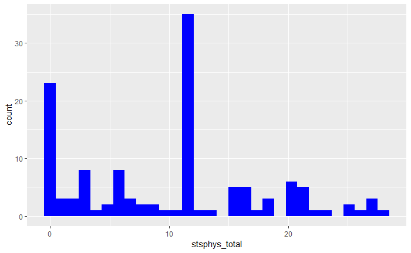

```r
ggplot(data = regression.dat, mapping = aes(stsphys_total)) +
  geom_histogram(fill = "blue")
```

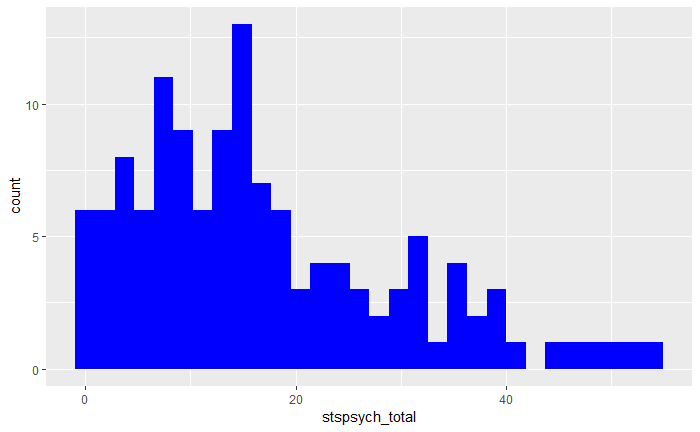

```r
ggplot(data = regression.dat, mapping = aes(stspsych_total)) +
  geom_histogram(fill = "blue")
```

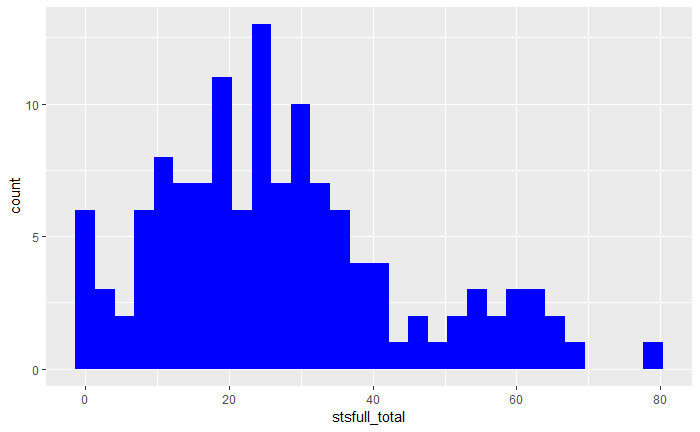

```r
ggplot(data = regression.dat, mapping = aes(stsfull_total)) +
  geom_histogram(fill = "blue")
```

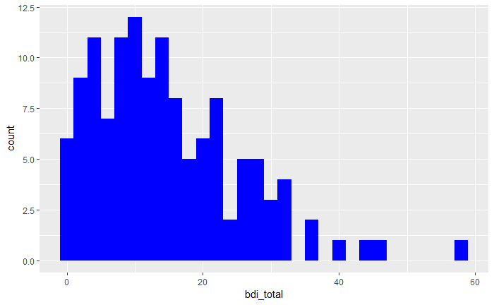

```r
ggplot(data = regression.dat, mapping = aes(bdi_total)) +
  geom_histogram(fill = "blue")
```

Descriptive stats for 4 variables

Create data frame with 4 variables for regression

```r
describe_reg.dat <- dplyr::select(regression.dat, stsphys_total, stspsych_total, stsfull_total, bdi_total)
```

Run descriptive stats:

```r
describe(describe_reg.dat)
```

|  | vars | n | mean | sd | median | trimmed | mad | min | max | range | skew | kurtosis | se |
| --- | --- | --- | --- | --- | --- | --- | --- | --- | --- | --- | --- | --- | --- |
| stsphys_total | 1 | 128 | 10.15 | 7.69 | 12 | 9.67 | 8.90 | 0 | 28 | 28 | 0.31 | -0.75 | 0.68 |
| stspsych_total | 2 | 128 | 16.97 | 12.81 | 14 | 15.71 | 11.12 | 0 | 54 | 54 | 0.88 | 0.10 | 1.13 |
| stsfull_total | 3 | 128 | 27.12 | 17.15 | 25 | 25.80 | 14.83 | 0 | 79 | 79 | 0.72 | 0.04 | 1.52 |
| bdi_total | 4 | 128 | 15.23 | 10.78 | 13 | 14.27 | 10.38 | 0 | 58 | 58 | 1.00 | 1.21 | 0.95 |

Regression 1: Phys sep vs depression

```r
stsphys_depression.reg <- lm(bdi_total ~ stsphys_total, regression.dat)
summary(stsphys_depression.reg)
```

```
Call:
lm(formula = bdi_total ~ stsphys_total, data = regression.dat)

Residuals:
<Labelled double>
    Min      1Q  Median      3Q     Max
-16.422  -7.833  -2.259   6.212  42.635

Labels:
```

|  | value | label |
| --- | --- | --- |
| I do not feel sad | 0 | I do not feel sad |
| I feel sad much of the time | 1 | I feel sad much of the time |
| I am sad all of the time. | 2 | I am sad all of the time. |
| I am so sad or unhappy that I can't stand it. | 3 | I am so sad or unhappy that I can't stand it. |

```
Coefficients:
              Estimate Std. Error t value Pr(>|t|)
(Intercept)   14.51939    1.58601   9.155 1.24e-15 ***
stsphys_total  0.07045    0.12476   0.565    0.573
---
Signif. codes:  0 ‘***’ 0.001 ‘**’ 0.01 ‘*’ 0.05 ‘.’ 0.1 ‘ ’ 1

Residual standard error: 10.81 on 126 degrees of freedom
Multiple R-squared:  0.002524,  Adjusted R-squared:  -0.005392
F-statistic: 0.3189 on 1 and 126 DF,  p-value: 0.5733
```

STS phys does not significantly predict depression. Also the distribution of the scores for the phys sep subscale does not meet the assumption of normal distribution neccessary for a linear regression

Regression 2: Psych sep vs depression

```r
stspsych_depression.reg <- lm(bdi_total ~ stspsych_total, regression.dat)
summary(stspsych_depression.reg)
```

```
Call:
lm(formula = bdi_total ~ stspsych_total, data = regression.dat)

Residuals:
<Labelled double>
    Min      1Q  Median      3Q     Max
-23.382  -7.044  -1.265   6.247  34.851

Labels:
```

|  | value | label |
| --- | --- | --- |
| I do not feel sad | 0 | I do not feel sad |
| I feel sad much of the time | 1 | I feel sad much of the time |
| I am sad all of the time. | 2 | I am sad all of the time. |
| I am so sad or unhappy that I can't stand it. | 3 | I am so sad or unhappy that I can't stand it. |

```
Coefficients:
               Estimate Std. Error t value Pr(>|t|)
(Intercept)    11.28784    1.52937   7.381 1.87e-11 ***
stspsych_total  0.23258    0.07204   3.229  0.00159 **
---
Signif. codes:  0 ‘***’ 0.001 ‘**’ 0.01 ‘*’ 0.05 ‘.’ 0.1 ‘ ’ 1

Residual standard error: 10.4 on 126 degrees of freedom
Multiple R-squared:  0.07641,   Adjusted R-squared:  0.06908
F-statistic: 10.42 on 1 and 126 DF,  p-value: 0.001587
```

Psych sep is significantly predictive of depression, but with a fairly small effect size (F = 10.42, p = 0.002, r-squared = 0.08)

Regression 3: Full sep vs depression

```r
stsfull_depression.reg <- lm(bdi_total ~ stsfull_total, regression.dat)
summary(stsfull_depression.reg)
```

```
Call:
lm(formula = bdi_total ~ stsfull_total, data = regression.dat)

Residuals:
<Labelled double>
    Min      1Q  Median      3Q     Max
-22.697  -7.269  -1.930   5.971  37.604

Labels:
```

|  | value | label |
| --- | --- | --- |
| I do not feel sad | 0 | I do not feel sad |
| I feel sad much of the time | 1 | I feel sad much of the time |
| I am sad all of the time. | 2 | I am sad all of the time. |
| I am so sad or unhappy that I can't stand it. | 3 | I am so sad or unhappy that I can't stand it. |

```
Coefficients:
              Estimate Std. Error t value Pr(>|t|)
(Intercept)   11.33373    1.74642    6.49 1.79e-09 ***
stsfull_total  0.14384    0.05449    2.64  0.00934 **
---
Signif. codes:  0 ‘***’ 0.001 ‘**’ 0.01 ‘*’ 0.05 ‘.’ 0.1 ‘ ’ 1

Residual standard error: 10.53 on 126 degrees of freedom
Multiple R-squared:  0.05241,   Adjusted R-squared:  0.04489
F-statistic: 6.969 on 1 and 126 DF,  p-value: 0.009342
```

## Full sep is significantly predictive of depression, but with a very small effect size (F = 6.97, p = 0.009, r-squared = 0.05). The drop in effect size between the psych sep subscale and the full sep scale suggests that the psych sep subscale is more useful as a predictive tool on it’s own.

Investigate relationships visually:

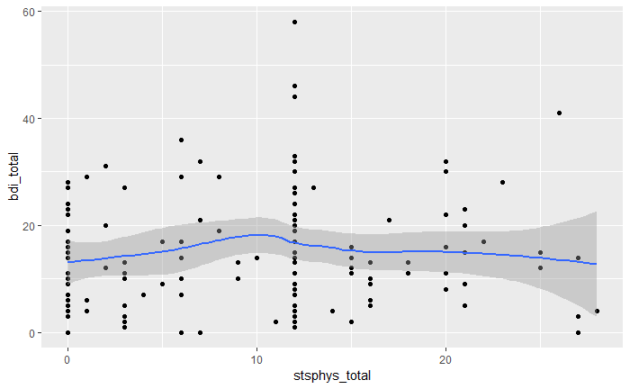

```r
ggplot(data = regression.dat, mapping = aes(x = stsphys_total, y = bdi_total))+
  geom_point()+
  geom_smooth()
```

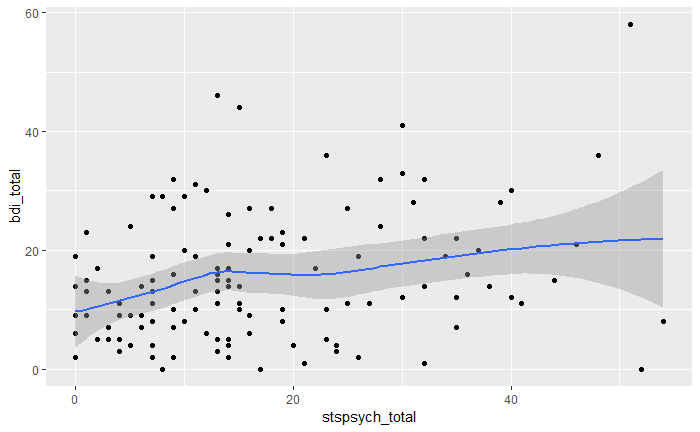

```r
ggplot(data = regression.dat, mapping = aes(x = stspsych_total, y = bdi_total))+
  geom_point()+
  geom_smooth()
```

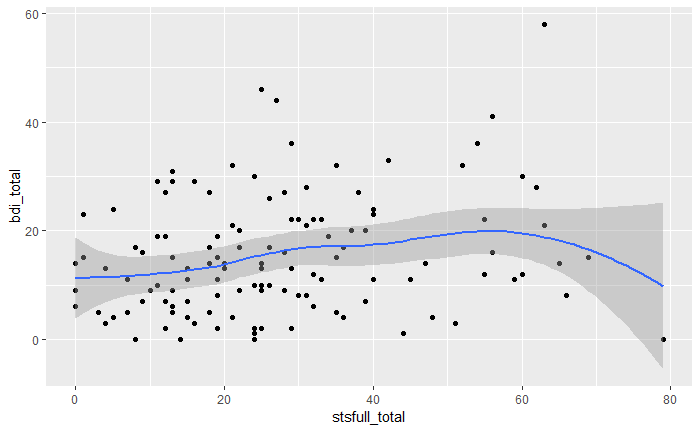

```r
ggplot(data = regression.dat, mapping = aes(x = stsfull_total, y = bdi_total))+
  geom_point()+
  geom_smooth()
```

Investigate distributions for scales:

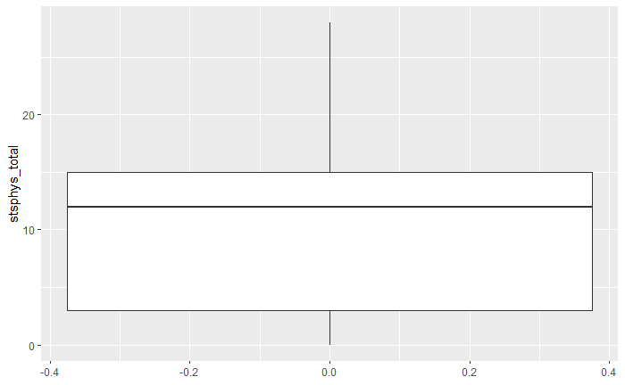

```r
ggplot(data = regression.dat, mapping = aes(y = stsphys_total))+
  geom_boxplot()
```

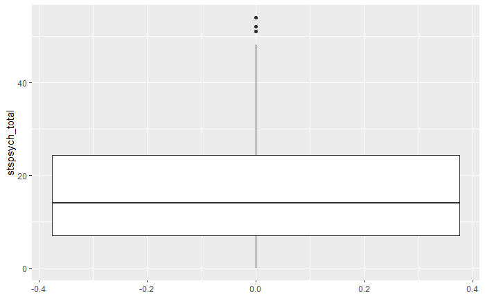

```r
ggplot(data = regression.dat, mapping = aes(y = stspsych_total))+
  geom_boxplot()
```

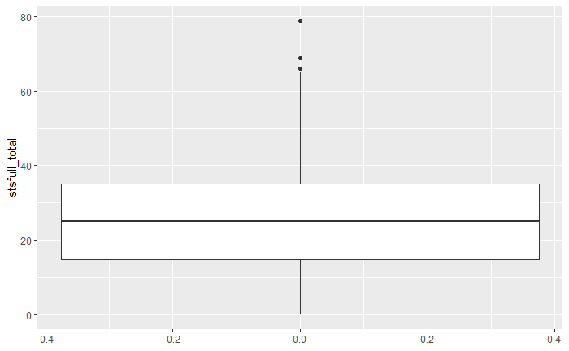

```r
ggplot(data = regression.dat, mapping = aes(y = stsfull_total))+
  geom_boxplot()
```

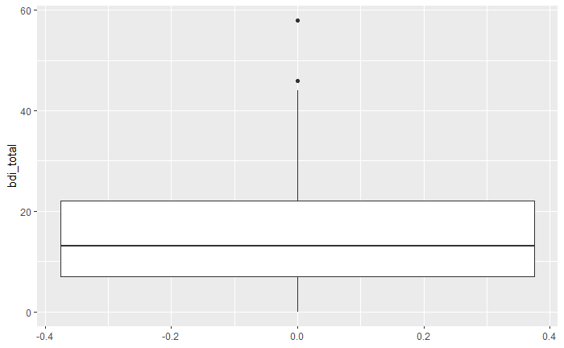

```r
ggplot(data = regression.dat, mapping = aes(y = bdi_total))+
  geom_boxplot()
```